# Homework_6

Final Project Draft - ATP PEW

Lenna Garibian  
May 2022

### Introduction

The objective of this study is to explore American views on democracy, and the kind of role Americans want their government to have in the world, and to hypothesize how current events might sway Americans’ views.

The question is interesting in light of Russia’s invasion of Ukraine beginning in late February 2022, and America’s response to the conflict. With Russia as the clear aggressor, the US has been supportive of Ukraine. Soon after the war began, the US government asserted its role in the international sphere, issuing a set of relatively punishing economic sanctions against Russia. Notably, both major political parties coalesced around policies in support of Ukraine, signifying some level of agreement and willingness to collaborate around the shared purpose of Ukrainian self-determination. American sentiment followed suit, undoubtedly due at least in some part to the media campaign of the Ukrainian government, led by Ukrainian President Volodymyr Zelensky.

Moreover, a new [Pew Poll](https://www.pewresearch.org/politics/2022/03/15/public-expresses-mixed-views-of-u-s-response-to-russias-invasion-of-ukraine/), conducted in March 2022 shows that Americans favor strong support Ukraine: A plurality (42%) of Americans say the US should be providing MORE support to Ukraine. A third (32%) of Americans say that the US is providing about the right amount of support, while only 7% say the US is providing too much support to Ukraine as it fights to hold off the Russian invasion.

This analysis is a look back at American views on democracy, before the recent evens in Ukraine. The [Pew Research](https://www.pewresearch.org/) poll on which the study is based was fielded in February 2021, during the COVID pandemic and while the US was still engaged in the protracted conflict in Afghanistan.

With this context, this study explores the following:

- Given that so much of the justification for supporting Ukraine has been defending American ideals of [democracy](https://www.nytimes.com/video/world/europe/100000008273587/biden-putin-speech-ukraine-russia.html) around the world, we ask how do Americans feel about their own US democracy, and is US democracy a good model for other countries to follow?
- How do Americans feel about the US Government’s involvement abroad?
- How do Americans feel about the US President compared with other major leaders abroad, and what do they think American priorities should be about?
- Finally, to the extent that we can tell, did Russia’s bold advances into Ukraine change Americans views on US engagement abroad?

**Libraries**

```r
knitr::opts_chunk$set(echo = TRUE)
library(dplyr)
library(tidyr)
library(ggplot2)
library(haven)
library(formattable)
library(tidyverse)
library(scales)
library(treemap)
library(rmarkdown)
```

### Data

Pew Research distributes its data as a .sav file, which is an SPSS format. Files with the .sav extension require the haven library. From the initial atp.sav file, I created upwards of a dozen data-frames for different types of analyses. For this project, I use descriptive statistics - describing the results of survey data across various segments.

I initially read in about 15 variables, conducted basic analysis, and then settled the following for analysis: - Satisfaction with US democracy (GAP21Q3) - US democracy as a model for other countries (GAP21Q6) - Confidence in world leadership (GAP21Q19a to GAP21Q19e) - Leadership role for US (GAP21Q29) - Long-range policy goals (GAP21Q33a to GAP21Q33t) - American engagement in world affairs (GAP21Q37) - Education levels (F_EDUCCAT) - Political orientation (F_PARTYSUMIDEO)

This final project includes the analysis by political orientation only, which proved the most helpful from a storytelling perspective.

The primary tidying tasks I performed were:

- Selecting and renaming key variables
- Pivoting longer to clean the data for analysis
- Grouping and summarizing data to assess counts, frequencies, and percentages
- Re-coding, arranging and filtering data for clarity

### Visualizing the data

The choices to visualize these data frames were done through trial and error. In most cases, I tried multiple methods, ultimately landing on the one I thought was easiest to make sense of. What I learned through that process is sometimes to coolest graph is the least helpful, and there’s a reason why bar charts are so popular - their easy to make sense of. I also added facet wrapping, as well as a tree map - which proved the helpful to show nuances by political orientation when there were so many answer options.

**Reading in Data**

```r
atp <- read_sav("ATP W82.sav",user_na = TRUE) %>%
         as_factor()
```

**Selecting Variables**

```r
atp_selected <- atp %>%
select(GAP21Q3_W82,
       GAP21Q6_W82,
       GAP21Q19_a_W82,
       GAP21Q19_b_W82,
       GAP21Q19_c_W82,
       GAP21Q19_d_W82,
       GAP21Q19_e_W82,
       GAP21Q29_W82,
      GAP21Q35_W82,
      GAP21Q37_W82,
      F_EDUCCAT,
      F_PARTYSUMIDEO)
```

**Renaming Variables**

```r
atp_selected <- atp_selected %>%
  rename(US_Democracy = GAP21Q3_W82,
         US_example = GAP21Q6_W82,
         US_leadership = GAP21Q29_W82,
         Intl_Collaboration = GAP21Q35_W82,
         Home_vs_Abroad = GAP21Q37_W82,
         US_Biden_Confidence = GAP21Q19_a_W82,
         Chinese_Jinping_Confidence = GAP21Q19_b_W82,
         Russian_Putin_Confidence = GAP21Q19_c_W82,
         German_Merkel_Confidence = GAP21Q19_d_W82,
         French_Macron_Confidence = GAP21Q19_e_W82)
```

### American Perceptions of US Democracy

A majority of Americans (58%) are unsatisfied with US democracy. Only 2 in 5 (41%) say they’re satisfied with US democracy, with only 6% saying they’re very satisfied.

**Transforming Data**

```r
democracy <- atp_selected %>%

select("US_Democracy") %>%
  group_by(US_Democracy) %>%
summarise(count = n()) %>%
  mutate(percent = count/sum(count) * 100) %>%
    filter(US_Democracy%in% c("Very satisfied", "Somewhat satisfied",
                              "Not too satisfied", "Not at all satisfied")) %>%
  arrange(factor (US_Democracy, levels = c("Very satisfied", "Somewhat satisfied",
                                           "Not too satisfied", "Not at all satisfied")))
```

**Visualizing Data**

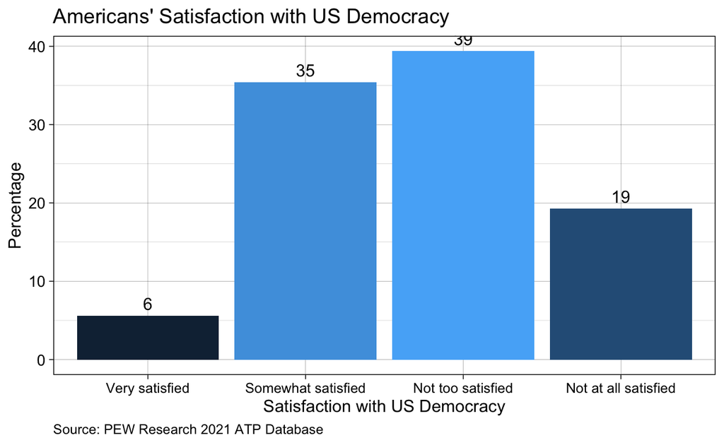

```r
ggplot(democracy, aes(x = US_Democracy, y = percent, fill = percent))+
  geom_bar(stat = "identity")+
theme_bw()+
  labs(x="Satisfaction with US Democracy", y="Percentage",
       title="Americans' Satisfaction with US Democracy",
       caption = "Source: PEW Research 2021 ATP Database")+
      theme_linedraw() +
  geom_text(aes(label= round(percent,0)),vjust = -.50)+
    theme(axis.text.x = element_text( size = 9),
          axis.text.y = element_text( size = 10),
          text = element_text(size = 11),
         legend.position="none",
          plot.caption = element_text(hjust = 0))
```

### US Democracy as Example for Other Countries

With so few Americans happy with our own democracy, it’s not surprising that only 1 in 5 Americans (21%) feel the US is a good model of democracy for other countries to follow.

**Transforming Data**

```r
USexampleC <- atp_selected %>%
  select("US_example") %>%
  group_by(US_example) %>%
summarise(count = n()) %>%
  mutate(percent = count/sum(count) * 100) %>%
mutate(US_example = case_when(
         US_example == "Is a good example for other countries to follow" ~ "Is a good example",
         US_example == "Used to be a good example, but has not been in recent years" ~ "Used to be a good example",
         US_example == "Has never been a good example for other countries to follow" ~ "Has never been a good example"))
```

**Visualizing Data**

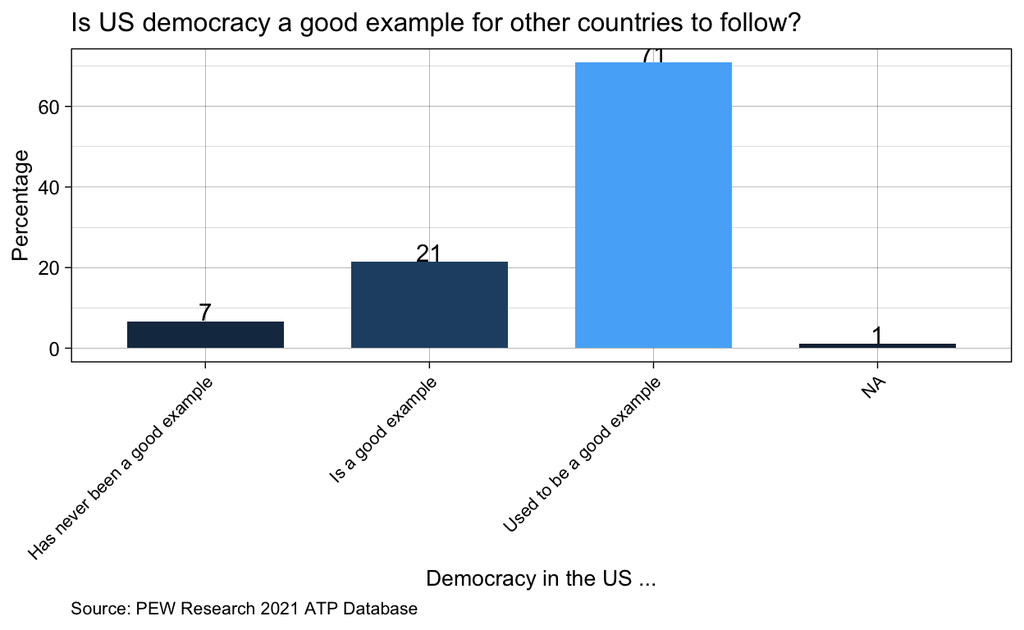

```r
ggplot(USexampleC, aes(x = US_example, y = percent, fill = percent))+
  geom_bar(stat = "identity", width=0.7)+
theme_bw()+
  labs(x="Democracy in the US ...", y="Percentage",
       title="Is US democracy a good example for other countries to follow?",
       caption = "Source: PEW Research 2021 ATP Database")+
      theme_linedraw() +
  geom_text(aes(label= round(percent,0)),vjust = -.050)+
    theme(axis.text.x = element_text( size = 8, angle = 45, hjust = 1),

          axis.text.y = element_text( size = 9),
          text = element_text(size = 10),
          legend.position = "none",
          plot.caption = element_text(hjust = 0))
```

### US Policy Priorities at Home and Abroad

Among all Americans, spreading US democracy ranks lowest in US policy priorities. Even while the [global decline of democracy has accelerated](https://fsi.stanford.edu/news/understanding-global-rise-authoritarianism), only a small handful of Americans view spreading US democracy as a pressing policy goal.

Goals such as improving American jobs, reducing infectious diseases, and protecting the US from terror are far more pressing for Americans. While spreading democracy is far from top of mind, Americans are concerned about curtailing the power of countries such as China, Iran, and Russia.

**Selecting New Variables**

```r
atp_policy_All <- atp %>%
select(GAP21Q33_a_W82,
      GAP21Q33_b_W82,
      GAP21Q33_c_W82,
      GAP21Q33_d_W82,
      GAP21Q33_e_W82,
      GAP21Q33_f_W82,
      GAP21Q33_g_W82,
      GAP21Q33_h_W82,
      GAP21Q33_i_W82,
      GAP21Q33_j_W82,
      GAP21Q33_k_W82,
      GAP21Q33_l_W82,
      GAP21Q33_m_W82,
      GAP21Q33_n_W82,
      GAP21Q33_o_W82,
      GAP21Q33_p_W82,
      GAP21Q33_q_W82,
      GAP21Q33_r_W82,
      GAP21Q33_s_W82,
      GAP21Q33_t_W82)
```

**Renaming Variables**

```r
atp_policy_All <- atp_policy_All %>%
  rename(Reduce_WeaponsMD = GAP21Q33_a_W82,
         American_Jobs = GAP21Q33_b_W82,
         Strengthen_UN = GAP21Q33_c_W82,
         Reduce_USMil_Overseas = GAP21Q33_d_W82,
         Limit_Russia_Power = GAP21Q33_e_W82,
         Promote_Democracy_Overseas = GAP21Q33_f_W82,
         Reduce_Illegal_Immigr = GAP21Q33_g_W82,
         Limit_China_Power = GAP21Q33_h_W82,
         Maintain_USMil_Advantage = GAP21Q33_i_W82,
         Global_Climate_Change = GAP21Q33_j_W82,
        Reduce_Trade_Deficit = GAP21Q33_k_W82,
      Promote_Human_Rights = GAP21Q33_l_W82,
      Reduce_Inf_Diseases = GAP21Q33_m_W82,
      Limit_Iran_Power = GAP21Q33_n_W82,
      Improve_Relations_Allies = GAP21Q33_o_W82,
      Protect_US_From_Terror = GAP21Q33_p_W82,
      Better_Share_Cost_World_Order = GAP21Q33_q_W82,
      Aide_Refugees_from_Violence = GAP21Q33_r_W82,
      Reduce_Legal_Immigr_to_US = GAP21Q33_s_W82,
      Limit_NKorea_Power = GAP21Q33_t_W82)
```

**Wrangling Data**

```r
atp_policy_All <- atp_policy_All %>%
select(c(1:20))
atp_policy_All <- pivot_longer(atp_policy_All, cols = c(Reduce_WeaponsMD,American_Jobs,Strengthen_UN,
                                    Reduce_USMil_Overseas, Limit_Russia_Power, Promote_Democracy_Overseas,
                                    Reduce_Illegal_Immigr, Limit_China_Power, Maintain_USMil_Advantage,
                                    Global_Climate_Change, Reduce_Trade_Deficit, Promote_Human_Rights,
                                    Reduce_Inf_Diseases,Limit_Iran_Power, Improve_Relations_Allies,
                                    Protect_US_From_Terror, Better_Share_Cost_World_Order,
                                    Aide_Refugees_from_Violence, Reduce_Legal_Immigr_to_US,
                                    Reduce_Legal_Immigr_to_US, Limit_NKorea_Power),
                                    names_to = "Policy-goals", values_to ="Level") %>%
 filter(Level%in% c("Top priority")) %>%
  group_by(`Policy-goals`,`Level`) %>%
  summarise(count = n()) %>%
  ungroup() %>%
     mutate(percent = count/sum(count) * 100)
```

**Visualizing Data**

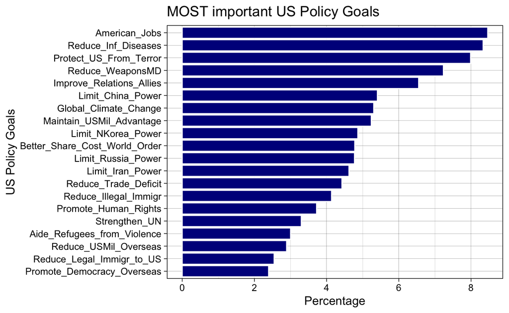

```r
ggplot(atp_policy_All, aes(x=reorder(`Policy-goals`, percent), y=`percent`))+
  geom_bar(fill = "blue4", color = "white",
           stat = "identity", position = position_dodge())+
  labs(x="US Policy Goals", y="Percentage", title = "MOST important US Policy Goals")+
  theme_linedraw() +
     # geom_text(aes(label= round(percent,1)),vjust = -2.9, hjust = -3.1) +
  coord_flip()
```

### The US as a Leader on the World Stage

Americans are hesitant to see its government assume world leadership: 8 in 10 want the US to share the role of leadership with other countries.

**Transforming Data**

```r
USLeadership_All <- atp_selected %>%
select(c(US_leadership))  %>%
  group_by(US_leadership) %>%
summarise(count = n()) %>%
  mutate(percent = count/sum(count) * 100) %>%
filter(US_leadership %in%c ("Be the single world leader","Play a shared leadership role",
                            "Not play any leadership role"))
paged_table(USLeadership_All)
```

| US_leadership | count | percent |
| --- | --- | --- |
| Be the single world leader | 294 | 11.325116 |
| Play a shared leadership role | 2064 | 79.506934 |
| Not play any leadership role | 209 | 8.050847 |

**Visualizing Data**

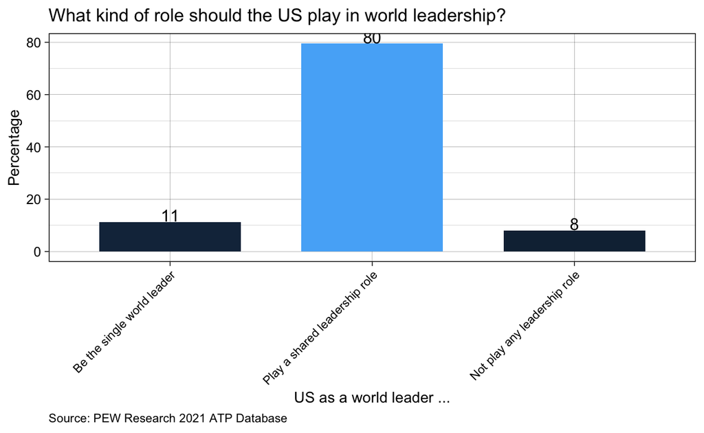

```r
ggplot(USLeadership_All, aes(x = US_leadership, y = percent, fill = percent))+
  geom_bar(stat = "identity", width=0.7)+
theme_bw()+
  labs(x="US as a world leader ...", y="Percentage",
       title="What kind of role should the US play in world leadership?",
       caption = "Source: PEW Research 2021 ATP Database")+
      theme_linedraw() +
  geom_text(aes(label= round(percent,0)),vjust = -.05)+
    theme(axis.text.x = element_text( size = 8, angle = 45, hjust = 1),
          axis.text.y = element_text( size = 9),
          text = element_text(size = 10),
          legend.position = "none",
          plot.caption = element_text(hjust = 0))
```

### Americans’ Confidence in World Leaders

Even while Americans want to share world leadership, they have far more confidence in President Biden and other Western leaders than non-Western leaders, such as Russian President Vladimir Putin and Chinese President Xi Jinping.

**Wrangling Data**

```r
Leadership <- atp_selected %>% select(US_Biden_Confidence,
                                      Chinese_Jinping_Confidence, Russian_Putin_Confidence,
                                      German_Merkel_Confidence, French_Macron_Confidence)
Leadership <- pivot_longer(Leadership, cols=c("US_Biden_Confidence",
                            "Chinese_Jinping_Confidence", "Russian_Putin_Confidence",
                            "German_Merkel_Confidence", "French_Macron_Confidence"),
                           names_to = "World_leaders", values_to = "Level")
```

**Transforming Data**

```r
Leadership <- Leadership %>%
  group_by(`World_leaders`, Level) %>%
  summarise(count = n()) %>%
  mutate(percent = count/sum(count) * 100) %>%
  filter(Level %in% c("A lot of confidence","Some confidence","Not too much confidence", "No confidence at all"))
paged_table(Leadership)
```

| World_leaders | Level | count | percent |
| --- | --- | --- | --- |
| Chinese_Jinping_Confidence | A lot of confidence | 29 | 1.117103 |
| Chinese_Jinping_Confidence | Some confidence | 296 | 11.402157 |
| Chinese_Jinping_Confidence | Not too much confidence | 1043 | 40.177196 |
| Chinese_Jinping_Confidence | No confidence at all | 1170 | 45.069337 |
| French_Macron_Confidence | A lot of confidence | 259 | 9.976888 |
| French_Macron_Confidence | Some confidence | 1355 | 52.195686 |
| French_Macron_Confidence | Not too much confidence | 650 | 25.038521 |
| French_Macron_Confidence | No confidence at all | 242 | 9.322034 |
| German_Merkel_Confidence | A lot of confidence | 592 | 22.804314 |
| German_Merkel_Confidence | Some confidence | 1149 | 44.260401 |

[output cut: 10 more lines]

**Visualizing Data**

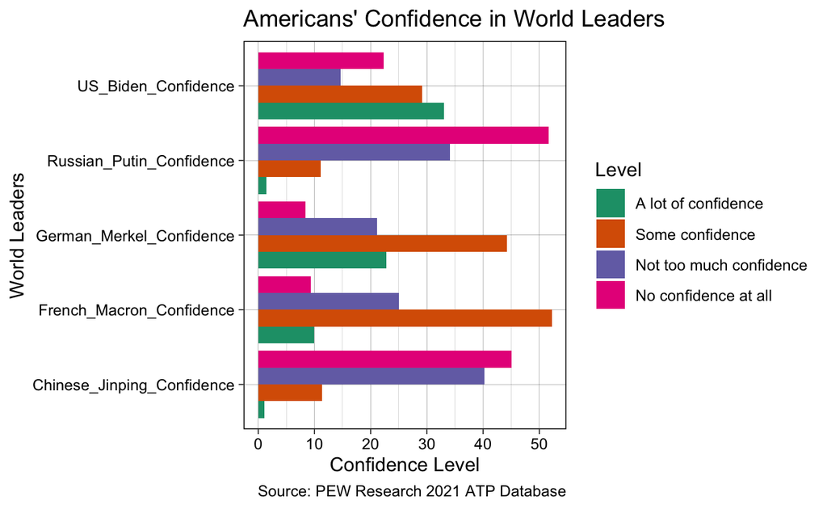

```r
ggplot(Leadership, aes(x=percent, y=World_leaders, fill=Level))+
geom_bar(stat = "identity", position = position_dodge())+
   scale_fill_brewer(palette = "Dark2")+
  labs(x="Confidence Level", y="World Leaders",
       title="Americans' Confidence in World Leaders",
       caption = "Source: PEW Research 2021 ATP Database")+
  theme_linedraw()
```

### Views on Collaborating with Other Countries to Solve Problems

In an increasingly global world, many Americans recognize the importance of international collaboration to solve problems:56% of Americans say MANY of the problems facing our country can be solved by working with other countries.

**Transforming Data**

```r
US_cooperation <- atp_selected %>%
  select(Intl_Collaboration) %>%
  mutate(Intl_Collaboration = recode(Intl_Collaboration, "MANY of the problems facing our country can be solved by working with other countries" = "MANY problems ...", "FEW of the problems facing our country can be solved by working with other countries" = "FEW problems ...")) %>%
  filter(Intl_Collaboration %in% c("MANY problems ...","FEW problems ...")) %>%
  group_by(Intl_Collaboration) %>%
summarise(count = n()) %>%
  mutate(percent = count/sum(count) * 100)
paged_table(US_cooperation)
```

| Intl_Collaboration | count | percent |
| --- | --- | --- |
| MANY problems ... | 1425 | 55.55556 |
| FEW problems ... | 1140 | 44.44444 |

**Visualizing Data**

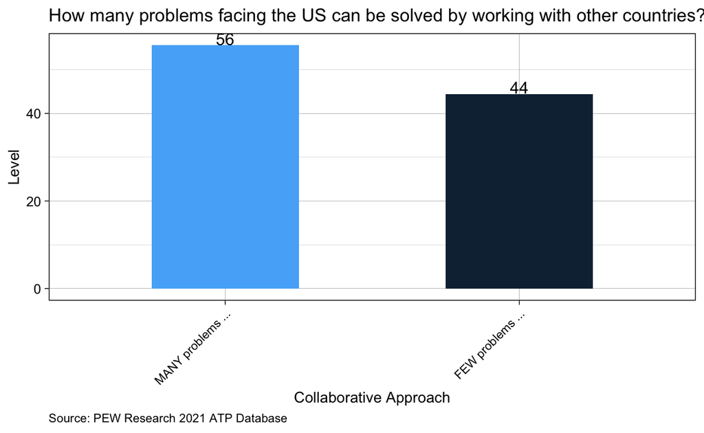

```r
ggplot(US_cooperation, aes(x = Intl_Collaboration, y = percent, fill = percent))+
  geom_bar(stat = "identity", width=0.5)+
theme_bw()+
    labs(x="Collaborative Approach", y="Level",
         title = "How many problems facing the US can be solved by working with other countries?",
       caption = "Source: PEW Research 2021 ATP Database")+
      theme_linedraw() +
  geom_text(aes(label= round(percent,0)),vjust = -.05)+
    theme(axis.text.x = element_text( size = 8, angle = 45, hjust = 1),
          axis.text.y = element_text( size = 9),
          text = element_text(size = 10),
          legend.position = "none",
          plot.caption = element_text(hjust = 0))
```

Republican/Conservative-Leaning Americans are far less bullish on international collaboration: Only 1 in 4 (27%) say our problems can be solved by working with other countries.

**Transforming Data**

```r
US_cooperation_polit_lean <- atp_selected %>%
    rename(Political_Orientation = F_PARTYSUMIDEO) %>%
  select(Political_Orientation,Intl_Collaboration) %>%
  mutate(Intl_Collaboration = recode(Intl_Collaboration, "MANY of the problems facing our country can be solved by working with other countries" = "MANY problems ...", "FEW of the problems facing our country can be solved by working with other countries" = "FEW problems ...")) %>%
  filter(Intl_Collaboration %in% c("MANY problems ...","FEW problems ...")) %>%
  group_by(Political_Orientation,Intl_Collaboration)%>%
summarise(count = n()) %>%
  mutate(percent = count/sum(count) * 100) %>%
  filter(Political_Orientation %in% c("Liberal Dem/Lean", "Conservative Rep/Lean"))
paged_table(US_cooperation_polit_lean)
```

| Political_Orientation | Intl_Collaboration | count | percent |
| --- | --- | --- | --- |
| Conservative Rep/Lean | MANY problems ... | 188 | 27.28592 |
| Conservative Rep/Lean | FEW problems ... | 501 | 72.71408 |
| Liberal Dem/Lean | MANY problems ... | 543 | 77.24040 |
| Liberal Dem/Lean | FEW problems ... | 160 | 22.75960 |

**Visualizing Data**

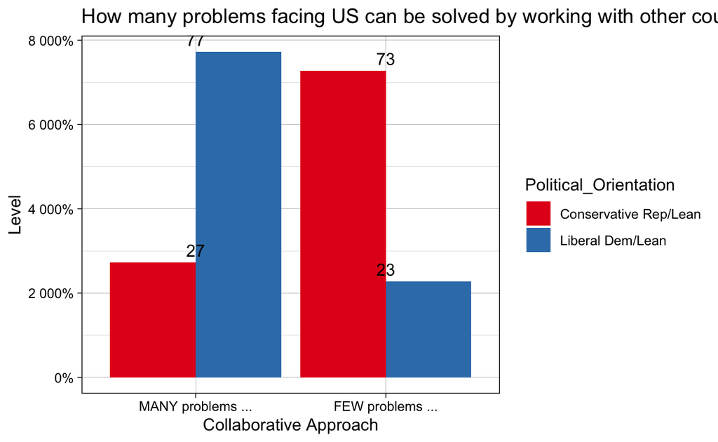

```r
ggplot(US_cooperation_polit_lean, aes(x=Intl_Collaboration, y=percent, fill=Political_Orientation))+
  geom_bar(stat = "identity", position = position_dodge())+
     scale_fill_brewer(palette = "Set1")+
  labs(x="Collaborative Approach", y="Level", title = "How many problems facing US can be solved by working with other countries?")+
     geom_text(aes(label= round(percent,0)),vjust= -.50)+
    scale_y_continuous(labels = scales::percent)+
 theme_linedraw()
```

### US Engagement in World Affairs, Political Orientation

Similarly, Americans are divided on how engaged the US should be in international affairs. Only 32% of Americans who lean Republican/Conservative say the US should be active in world affairs, compared with 75% of Democrat/Liberals who say so.

**Transforming Data**

```r
Problems_Abroad <- atp_selected %>%
    rename(Political_Orientation = F_PARTYSUMIDEO) %>%
  select(Political_Orientation, Home_vs_Abroad) %>%
  mutate(Home_vs_Abroad = recode(Home_vs_Abroad, "We should pay less attention to problems overseas and concentrate on problems here at home" = "Pay less attention to problems overseas", "It’s best for the future of our country to be active in world affairs" = "Be active in world affairs")) %>%
  filter(Home_vs_Abroad %in% c("Pay less attention to problems overseas","Be active in world affairs")) %>%
  group_by(Political_Orientation, Home_vs_Abroad)%>%
summarise(count = n()) %>%
  mutate(percent = count/sum(count) * 100) %>%
  filter(Political_Orientation %in% c("Liberal Dem/Lean", "Conservative Rep/Lean"))
paged_table(Problems_Abroad)
```

| Political_Orientation | Home_vs_Abroad | count | percent |
| --- | --- | --- | --- |
| Conservative Rep/Lean | Be active in world affairs | 223 | 32.27207 |
| Conservative Rep/Lean | Pay less attention to problems overseas | 468 | 67.72793 |
| Liberal Dem/Lean | Be active in world affairs | 529 | 75.14205 |
| Liberal Dem/Lean | Pay less attention to problems overseas | 175 | 24.85795 |

**Visualizing Data**

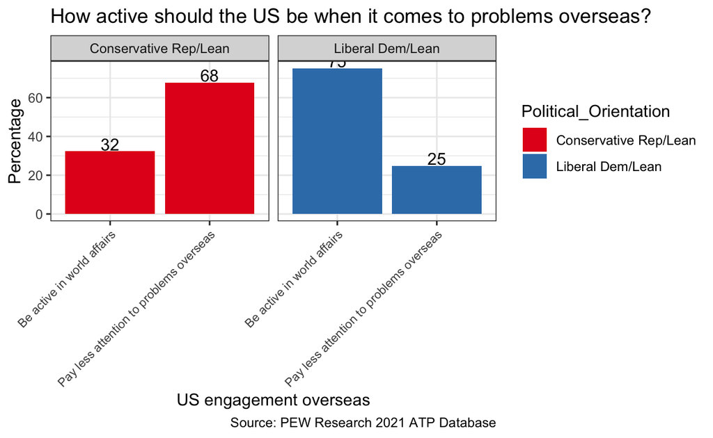

```r
 ggplot(Problems_Abroad, aes(x = Home_vs_Abroad, y = percent, fill = Political_Orientation))+
  geom_bar(stat = "identity")+
  facet_wrap(~Political_Orientation)+
 scale_fill_brewer(palette = "Set1")+
 theme_bw()+
   theme(axis.text.x = element_text( size = 8, angle = 45, hjust = 1))+
    labs(x="US engagement overseas", y="Percentage",
       title="How active should the US be when it comes to problems overseas?",
       caption = "Source: PEW Research 2021 ATP Database")+
guides(color = guide_legend(title = "Political Orientation"))+
  geom_text(aes(label= round(percent,0)), vjust = -.10)
```

### US Policy Priorities at Home and Abroad, by Political Orientation

With Republican/Conservative leaning Americans more reticent about being engaged in world affairs, it is not surprising that they are far more concerned than Democrat/Liberal-leaning Americans with inward facing issues, such as Protecting American Jobs, Maintaining US Military Advantage, Reducing Immigration, and Sharing the Cost of World Order.

While Republican/Conservative leaning Americans are more concerned that Democrat/Liberal-leaning Americans with limiting the power of powers China and Iran, they are less concerned with Russian influence.

By contrast, Democrat/Liberal-leaning Americans are more concerned with outward-facing issues, such as Strengthening the UN, Promoting Human Rights, and Improving Relations with Allies.

**Selecting Variables into a New Data Frame**

```r
atp_policy <- atp %>%
select(GAP21Q33_a_W82,
      GAP21Q33_b_W82,
      GAP21Q33_c_W82,
      GAP21Q33_d_W82,
      GAP21Q33_e_W82,
      GAP21Q33_f_W82,
      GAP21Q33_g_W82,
      GAP21Q33_h_W82,
      GAP21Q33_i_W82,
      GAP21Q33_j_W82,
      GAP21Q33_k_W82,
      GAP21Q33_l_W82,
      GAP21Q33_m_W82,
      GAP21Q33_n_W82,
      GAP21Q33_o_W82,
      GAP21Q33_p_W82,
      GAP21Q33_q_W82,
      GAP21Q33_r_W82,
      GAP21Q33_s_W82,
      GAP21Q33_t_W82,
      F_PARTYSUMIDEO)
```

**Renaming Variables**

```r
atp_policy <- atp_policy %>%
  rename(Reduce_WeaponsMD = GAP21Q33_a_W82,
         American_Jobs = GAP21Q33_b_W82,
         Strengthen_UN = GAP21Q33_c_W82,
         Reduce_USMil_Overseas = GAP21Q33_d_W82,
         Limit_Russia_Power = GAP21Q33_e_W82,
         Promote_Democracy_Overseas = GAP21Q33_f_W82,
         Reduce_Illegal_Immigr = GAP21Q33_g_W82,
         Limit_China_Power = GAP21Q33_h_W82,
         Maintain_USMil_Advantage = GAP21Q33_i_W82,
         Global_Climate_Change = GAP21Q33_j_W82,
        Reduce_Trade_Deficit = GAP21Q33_k_W82,
      Promote_Human_Rights = GAP21Q33_l_W82,
      Reduce_Inf_Diseases = GAP21Q33_m_W82,
      Limit_Iran_Power = GAP21Q33_n_W82,
      Improve_Relations_Allies = GAP21Q33_o_W82,
      Protect_US_From_Terror = GAP21Q33_p_W82,
      Better_Share_Cost_World_Order = GAP21Q33_q_W82,
      Aide_Refugees_from_Violence = GAP21Q33_r_W82,
      Reduce_Legal_Immigr_to_US = GAP21Q33_s_W82,
      Limit_NKorea_Power = GAP21Q33_t_W82,
      Political_Orientation = F_PARTYSUMIDEO)
```

**Wrangling Data**

```r
atp_policy <- atp_policy %>%
select(c(1:21))

atp_policy <- pivot_longer(atp_policy, cols = c(Reduce_WeaponsMD,American_Jobs,Strengthen_UN,
                                    Reduce_USMil_Overseas, Limit_Russia_Power, Promote_Democracy_Overseas,
                                    Reduce_Illegal_Immigr, Limit_China_Power, Maintain_USMil_Advantage,
                                    Global_Climate_Change, Reduce_Trade_Deficit, Promote_Human_Rights,
                                    Reduce_Inf_Diseases,Limit_Iran_Power, Improve_Relations_Allies,
                                    Protect_US_From_Terror, Better_Share_Cost_World_Order,
                                    Aide_Refugees_from_Violence, Reduce_Legal_Immigr_to_US,
                                    Reduce_Legal_Immigr_to_US, Limit_NKorea_Power),
                                    names_to = "Policy-goals", values_to ="Level") %>%

  group_by(`Policy-goals`,`Political_Orientation`, `Level`) %>%
    filter(Political_Orientation %in% c("Liberal Dem/Lean","Conservative Rep/Lean")) %>%
 filter(Level%in% c("Top priority")) %>%
  summarise(freq = n())  %>%
  ungroup() %>%
    mutate(percentage = formattable::percent(freq / sum(freq)))
head(atp_policy)
```

```
# A tibble: 6 × 5
  `Policy-goals`               Political_Orien… Level  freq percentage
  <chr>                        <fct>            <fct> <int> <formttbl>
1 Aide_Refugees_from_Violence  Conservative Re… Top …    25 0.40%
2 Aide_Refugees_from_Violence  Liberal Dem/Lean Top …   166 2.65%
3 American_Jobs                Conservative Re… Top …   326 5.20%
4 American_Jobs                Liberal Dem/Lean Top …   199 3.17%
5 Better_Share_Cost_World_Ord… Conservative Re… Top …   218 3.47%
6 Better_Share_Cost_World_Ord… Liberal Dem/Lean Top …    82 1.31%
```

**Visualizing Data**

```r
atp_policy %>%
  treemap(index=c("Policy-goals","Political_Orientation"),
                  vSize =  "percentage",
                  vColor = "Political_Orientation",
                  type = "categorical",
                  palette = "Set1",
                  title = "MOST important US Policy Goals",
                  fontsize.title = 14,
                  fontsize.labels = 10,
          fontsize.legend = 12,
position.legend = "bottom")
```

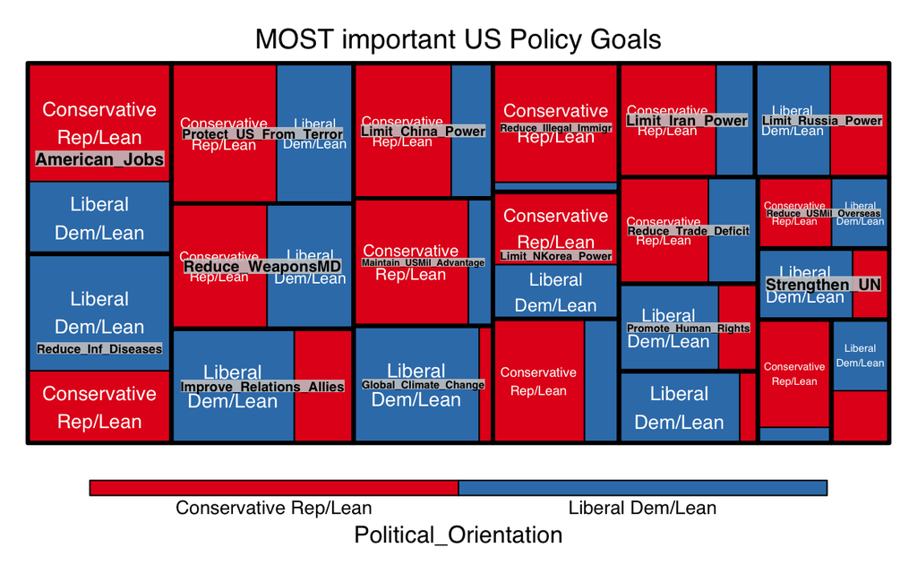

### Conclusion - WIP

The recent events of Russia’s invasion into Ukraine appear to have shifted American’s views on engaging on the world stage. Just one year prior, Americans, especially those who lean Republican/Conservative, were wary of reengaging in world affairs. Few Americans felt that US democracy was a good model for other countries, and even fewer had the appetite to engage with other countries to promote democracy overseas. Fast forward to today, the US Government and people are engaged again on world stage, in support of Ukrainian democracy.

This study raises questions. Is American sentiment really this fickle, or did other factors play a role in Americans’ hesitancy to engage? While President Donald Trump had left the US White House, his “America First” isolationist policies had gained traction among his supporters. Did this play a role? As mentioned, the complex, protracted conflicts in the Middle East offered Americans little hope that direct military engagement abroad could yield lasting impact. Were Americans simply tired of these types of conflicts.

A longitudinal look back at the data could shed light on this question, especially if measured alongside major current events (say the evacuation of US troops from Afghanistan). Pew data is generally available for public consumption several months after it first publishes the findings publicly. When available, The March 15, 2022 poll would also help to answer, as it polled Americans directly on support/handling of various policies.

**About the data:** Wave 82 American Trends Panel conducted by PEW RESEARCH CENTER via Web, among 2,596 English- and Spanish-speaking Americans, February 1-7, 2021.